# Part II - (GoFord Bike Key Findings Presentation)

## Dataset Overview

The data set contains:

- An id for each bicycle
- The trip duration in seconds
- Start time for the trip
- End time for the trip
- The id of the station where the trip started
- The name of the station where the trip started
- The latatitude of the start station
- The longitude of the start station
- The id of the station where the trip ended
- The name of the station where the trip ended
- The latatitude of the end station
- The longitude of the end station
- The users of the GoFord bike service (classified into customers and subscribers)
- The users' birth year
- The users' gender (classified into male, female and others)

Feature Engineering: This was carried out to further derive valuable information from the orignal dataset's variable. They include:

- Trip duration in minutes
- Trip duration in hours
- From users' birth year, users' age were determined
- Month the trip took place
- Days of the week
- Distance travelled in kilometer
- Speed in km/hr
- Geometry points
- Age group (classified into young adults, middle aged adults, seniors)

### Key Presentation 1

- Service usage difference between customers and subscribers.

> > This visualization shows how the users of GoFord Bike service are classified based on user type.

```
It shows that subcribers use the service way more than customers by 91% : 9%
```

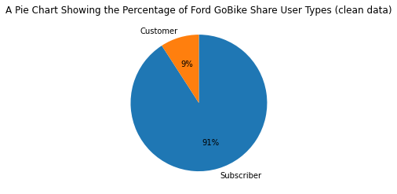

### Key Presentation 2

- user type vs distance: Does age group determine why customers' have a longer distance.

  > The charts show that age group cannot determine why customers' have a longer distance.

## (Visualization 2)

**Conclusion:**

[output not shown]

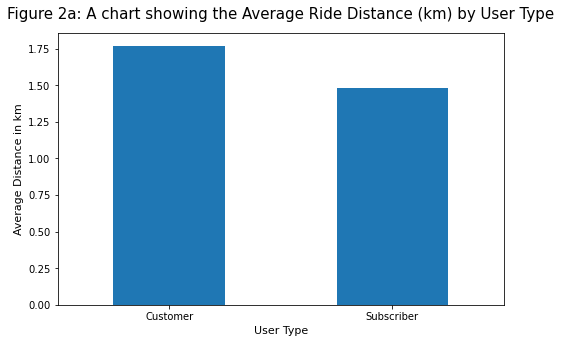

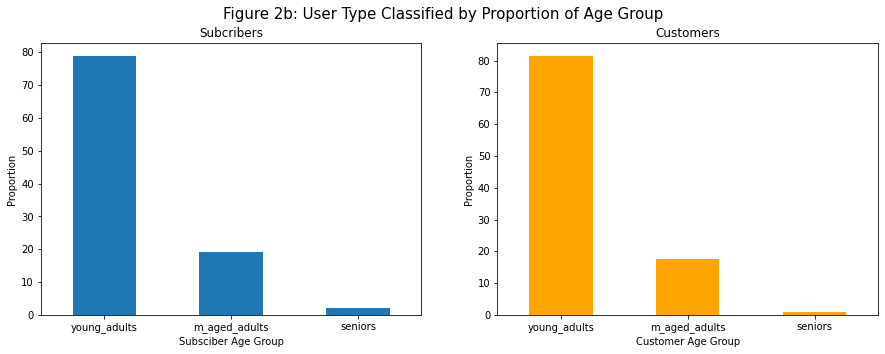

```
The chart shows that young adults have an higher proportion than other age groups for both user types.
 With subscribers having a higher amount of seniors than customers
```

```
 With figure 2a showing average Ride Distance (km) by User Type.
 Figure 2b shows the user type category being broken down into age groups.
 Figure 2c shows the speed of age groups.

 Relating figure 2c to figure 2b & 2a above; with young adults having a larger population and the highest average speed,this does not have an effect on customers' average distance travelled.

 Note:Since speed is relative, in this case, to distance. Speed is a good way to measure distance travelled and also to determine if age groups can determine customers' longer distance.
```

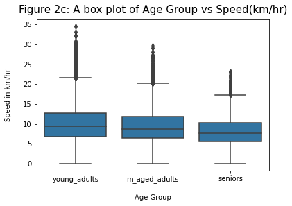

### Key Presentation 3

- age group vs (user type & distance): Giving more insights to the effect of speed and distance on age age group

## (Visualization 3)

> - This further buttresses the point that young adults are more likely to travel at a faster speed (and longer distances).
> - Young adults > middle aged adults > seniors.</br>
> - It is also important to note that distance peaks when users travel at a speed range of (14 - 20) km/hr

```
Conclusion: The chart clearly shows that young adults are more likely to travel longer distances at a faster speed but it shows no evidence on how this affected customers distance
```

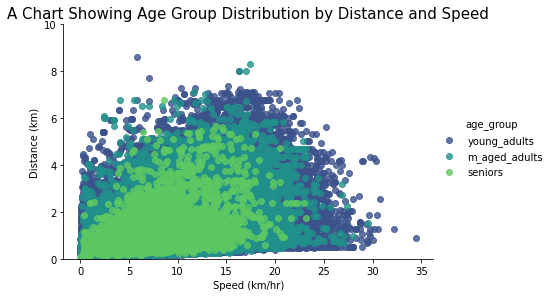